On the Class Size Trend Eﬀect on Student Performance in Early

Childhood Education

∗

Ziang Gao

1

, Adam Hetherwick

1

, Danny Kuei

1

, and Cody Vig

1

1

Department of Statistics, University of California, Davis.

{zggao, ajhetherwick, dkuei, cvig}@ucdavis.edu

March 16, 2026

Abstract

An analysis was performed on the dataset generated from the Project STAR (Student to

Teacher Achievement Ratio) experiment conducted on Tennessee elementary schools in the late

1980’s. Our analysis seeks to validate some of the signiﬁcant ﬁndings brought to light by past

research. Our work corroborates the existing literature by showing that students in smaller class

sizes produce statistically signiﬁcantly better kindergarten mathematics SAT scores when com-

pared to students in larger classes, especially for students from disadvantaged backgrounds. We

also expand upon the claims made by other researchers that small class sizes lead to diminishing

achievement gains over time by examining third-grade mathematics SAT scores among students

who did not comply with their assigned class size. We ﬁnd that neither the small-to-large class

cohort nor the large-to-small class cohort see signiﬁcantly better scores that those who stayed

in large classes all four years.

1 Background

1.1 Project STAR

Project STAR (Student to Teacher Achievement Ratio) was a large-scale, longitudinal, randomized

experiment conducted between 1985 and 1989 and examined the eﬀect of class size on student

performance in students’ early childhood education (kindergarten and early elementary school). All

schools were invited to participate and were required to have at least one of the following class

sizes: small (containing 13 to 17 students), regular (containing 22 to 26 students), or regular with

a full-time teacher’s aid.

The project was managed by the Tennessee State Department of Education and the research was

advised and operationally supported by researchers at four neighboring universities: Memphis State

∗

The code used to generate the data in this report can be found here: https://github.com/ucd-sta-207-project/ucd-

sta-207-project

1

University, Tennessee State University, the University of Tennessee at Knoxville, and Vanderbilt

University. Though the ideal would have been a perfectly random assignment of class sizes to

instructors and students to class sizes, not all schools agreed to or were capable of being part

of the study, so concessions were made. The project required participating schools to accept the

random assignment of teachers and students to diﬀerent class types, and all teachers had to be

certiﬁed for their grade level. Although about 180 schools initially expressed interest, only those

with suﬃcient kindergarten enrollment (at least 57 students) could participate because the study

used a within-school experimental design.

Ultimately, 79 schools across 42 school systems were selected to ensure representation across dis-

tricts, school types, and regions. In the 1986 academic year, the project included roughly 300

classes: 128 small classes (about 1,900 students), 101 regular classes (about 2,300 students), and 99

regular classes with teacher aides (about 2,200 students) [1].

1.2 Literature Review

Large scale randomized experiments are rare in the education sector. As such, this project has

been studied extensively and much insight has been gained from it. Research on class-size reduction

has developed substantially over the past several decades, and much of the evidence comes from

Project STAR. A large body of literature has used this dataset to evaluate both the short-term and

long-term consequences of early exposure to smaller classes, particularly for disadvantaged students.

Early research emphasizes the positive academic eﬀects of smaller classes in early grades. Jeremy

D. Finn (1998) [3] reviewed the existing literature on class-size reduction and focused particularly

on results emerging from Project STAR. The review concludes that smaller classes are associated

with higher academic achievement in early elementary school. The beneﬁts appear to be strongest

for students considered academically at risk, including those from low-income backgrounds and

historically disadvantaged groups. Finn notes that smaller classes may lead to greater student

engagement, participation, and eﬀort in the classroom, which he proposed as potential mechanisms

through which reduced class size contributes to improved learning outcomes. Finn went on to state

several open questions in the literature, including whether these early gains persist over time and

how multiple years of exposure to small classes inﬂuence longer-term academic trajectories.

Subsequent research has addressed these questions by examining the long-term consequences of early

class-size reductions. Using longitudinal data from Project STAR, Jeremy D. Finn et al. (2005)

[4] tracked nearly 5,000 students from kindergarten through high school to evaluate whether early

class size aﬀects the likelihood of graduating from high school. Their ﬁndings suggest that sustained

exposure to small classes in the early grades has signiﬁcant long-term beneﬁts. Students who spent

three or more years in small classes were statistically signiﬁcantly more likely to graduate than their

peers in larger classes. Four years of exposure to small class sizes was associated with an increase of

approximately 11.5 percentage points in high school graduation rates. Eﬀects were demonstrated to

be particularly pronounced for students from low-income backgrounds. The authors also ﬁnd that

early academic achievement is strongly correlated with eventual graduation, which suggests that

the short-term gains observed in smaller classes may contribute to improved long-term educational

attainment.

Diane Whitmore Schanzenbach (2007) [7] surveyed the existing literature generated by the exper-

2

iment and concluded that it provided credible experimental evidence on the eﬀects of class-size

reduction. Across numerous studies, the evidence universally indicates that smaller classes in the

early grades lead to statistically signiﬁcant improvements in student achievement. She further

corroborated that the largest beneﬁts appear among disadvantaged students (i.e., those from low-

income and minority backgrounds). The author also noted that students who begin in small classes

in kindergarten and remain in them for multiple years experience the largest gains, albeit with some

diminishing returns in the achievement improvements.

To summarize, the surrounding literature suggests that class-size reduction in the early elementary

grades produces statistically signiﬁcant academic beneﬁts across various socioeconomic and demo-

graphic variables, especially among at-risk students. The evidence from Project STAR demonstrates

both short-term improvements in student achievement and long-term gains in educational attain-

ment, including higher high school graduation rates.

2 Question of Interest

We see from Section 1 that it is well-understood based on the existing literature that smaller class

sizes yield statistically signiﬁcantly higher student achievement, both in the short-term and in the

long-term. Of particular interest to us is the remark by Schanzenbach [7] that the small-class

cohort sees diminishing returns in achievement gains in later years. We had hoped to expand

upon the existing literature by examining attrition among the small class cohort to see if most

of the achievement gain was retained among the students who left the small class pipeline early.

Unfortunately, as we will see in Section 3, attrition from the small class cohort was uncommon, i.e.,

most students who started in small classes stayed in small classes for the remainder of the study.

Although there is a nontrivial number of students who did leave small classes in favor of regular

ones, the sample size is small enough to risk substantial bias.

During this analysis, it was observed that attrition from the large class cohort to the small class

cohort was much more common. This could be due to parental intervention, in which some parents

request that their children not be disadvantaged by being placed in larger classrooms and be placed

in the smaller one in the next year. Nonetheless, this large attrition rate allows us to ask a similar

question about the potential achievement gains among students who joined the small class cohort

late.

As such, our analysis is twofold: corroborate the existing literature and expand upon it by address

attrition. To do this, we address the following questions:

1. Do smaller class sizes disproportionately beneﬁt low-income students in early elementary

school?

2. For students who begin their academic journey in regularly sized classrooms, is it educationally

advantageous to switch to smaller classes in later years?

In each case, we measure the student’s academic performance by their grades on the mathematics

portion of the Stanford Achievement Test (SAT).

3

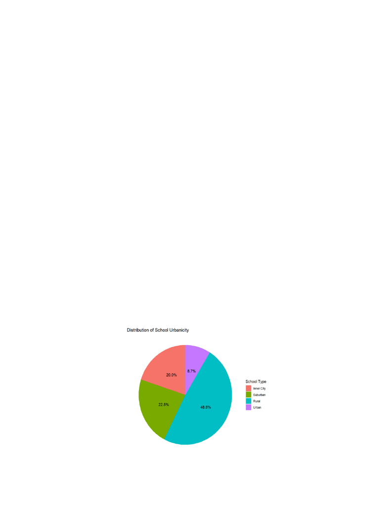

Answers to these questions have signiﬁcant implications on data-driven educational policies and

procedures. For instance, the analysis does to address question 2 could help inform intervention

strategies for struggling students in later years. These results may also alleviate budgeting con-

cerns associated with the implementation of smaller classrooms school-wide. If it turns out to be

advantageous to switch to a smaller classroom later in a student’s educational journey, it may be

wise to oﬀer smaller classrooms at certain grade levels. Analogously, if returns in achievement gains

diminish in later years among students whose educational journey is exclusively in small classrooms,

then it might be ﬁnancially beneﬁcial to oﬀer smaller class sizes only in the earliest grade levels.

3 Descriptive Analysis

3.1 Overview

Before conducting a formal statistical analysis, we ﬁrst explore the structure and key characteristics

of the dataset through exploratory data analysis. The purpose of this section is to understand the

distribution of school characteristics, student demographics, socioeconomic status, and academic

results.

3.2 School Characteristics

We begin by examining the distribution of school environments. Figure 1 shows the distribution

This variation in school location suggests that students in the dataset are given diﬀerent educational

context due to the location of schools, because the school environment may inﬂuence the available

resources and learning conditions. So, school urbanicity is included as one of the explanatory factors

in our ANOVA model.

Figure 1: Distribution of School Urbanicity

4

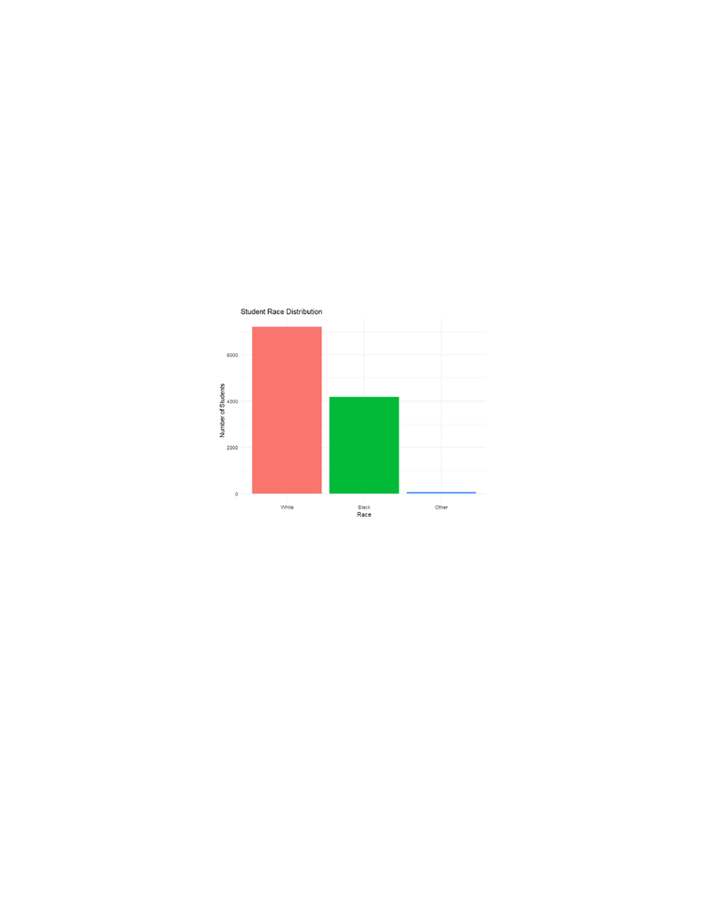

3.3 Student Demographics

Next, we examine the demographic composition of students. As shown in Figure 2, the racial

distribution indicates that White students represent the largest portion of the sample, followed by

Black students, while other racial groups account for a relatively small share of observations.

Due to the limited sample sizes of the other race groups, including them in the subsequent analysis

would generate potentially substantial bias. As such, racial groups other than White and Black

were removed from the dataset before conducting any statistical inference.

These demographic characteristics are relevant because diﬀerences in student background can be

associated with variation in academic performance. Therefore, race and gender are included as

explanatory variables in the mixed eﬀects model.

Figure 2: Distribution of Student Race

3.4 Socioeconomic Status

Socioeconomic status (SES) is measured using the percentage of students receiving free or reduced-

price lunch. Schools with higher percentages of students receiving free lunch are considered to have

lower socioeconomic status.

The histogram of free lunch percentages (Figure 3) shows substantial variation in SES across schools.

Many schools fall within the middle SES range, while a considerable number belong to lower SES

categories. For visualization purposes in the EDA, we categorize schools into SES groups based on

the free lunch percentage. However, in the subsequent analysis, we use the continuous free lunch

percentage variable as the key explanatory variable in both the ANOVA model and the mixed-eﬀects

model.

5

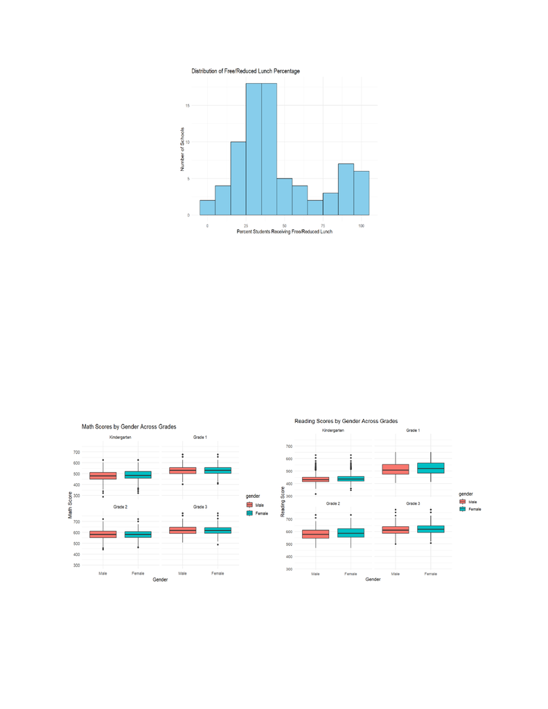

Figure 3: Distribution of Student receivng free lunch

3.5 Student Test Score Distributions

Next, we examine the distribution of student academic outcomes. Boxplots of math and reading

scores across grades and gender reveal several patterns.

Consider Figure 4. First, average test scores increase as students progress from kindergarten to grade

three, reﬂecting expected academic development over time. Second, the distributions of scores for

male and female students appear relatively similar across grades. These patterns provide an initial

overview of the data and help us understand the distribution of outcomes before we move on to

more formal statistical analysis examining the eﬀects of class size.

(a) Math Scores Across Grade (b) Reading Scores Across Grade

Figure 4: Test Scores Across Grades

Figures 4a and 4b show the similarity between reading and math test scores. We notice that all

6

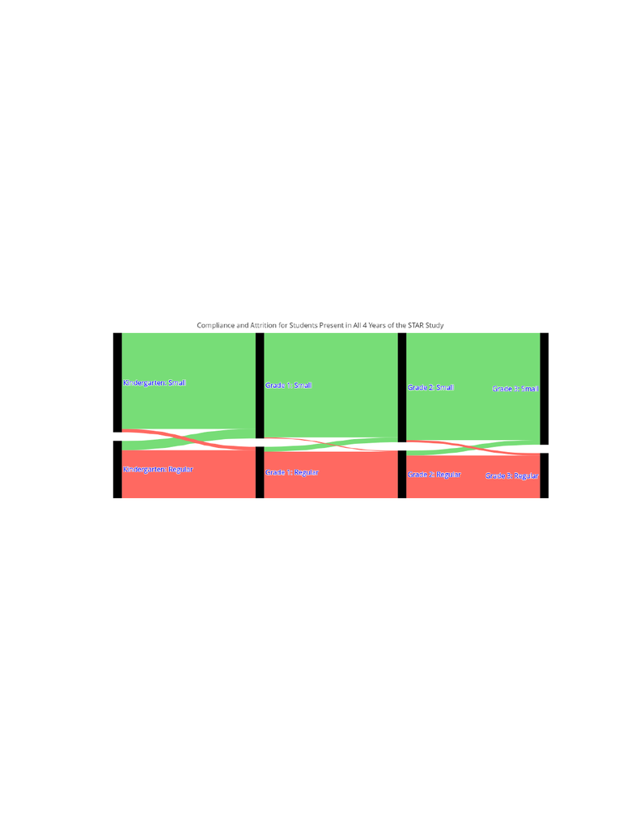

grades display relatively similar relationships to each other and distributions among students. We

also notice that the scaled test scores increase for both math and reading as students advance to

higher grades. This coincides with the information stated in the Project STAR Summary Report

3.6 Non-Compliance

Figure 5 shows the pipeline students who persisted through all four years of the experiment took.

Note that students who did not participate in all four years of the experiment (e.g., those that

transferred to a diﬀerent, non-participating school before completing the third grade) have been

removed from the diagram and from the analysis altogether. Additionally, for the present analysis

we ignored all students who took classes in regularly sized classrooms with a full-time teacher’s aid.

This decision was made to isolate the small class size eﬀect and to eliminate the additional variance

that would be generated by combining the two regular class size groups.

Figure 5: Attrition and throughput among students who persisted in the experiment through all four years. Those that

transferred out of the system early or joined late have been removed. Students in regularly sized classes with a full-time

teacher’s aid have also been removed.

It is apparent that the signiﬁcant majority of students who started on a particular path, stayed on

that path for the remainder of the experiment. It is also apparent that the small class size cohort was

substantially larger than the regular class size cohort. Finally, noncompliance is present, but it is

comparatively small. Of interest, most students who did not comply with their class size allocation

switched from large class sizes to smaller ones. This could be due to more academically conscious

parents advocating for their children to be given the best possible treatment, or potentially due to

counselor recommendation for students who were struggling in regularly sized classrooms. Attrition

from small class sizes to larger ones is almost completely negligible, especially after the Kindergarten

to Grade 1 transition.

7

[figure not shown]

3.7 Summary

Overall, the exploratory analysis highlights meaningful variation in school environment, socioeco-

nomic status, and student performance. These patterns motivate the modeling strategy used in the

next section, where we estimate the eﬀects of class size, free lunch status, and school urbanicity

using a three-factor ANOVA model, and further examine student-level trends using a mixed eﬀects

model.

4 Inferential Analysis

4.1 Three Way ANOVA Model

To evaluate the relationship between small class size and socioeconomic status, we initially ﬁt a

preliminary ﬁxed ANOVA model 1 with kindergarten math scores as the outcome. Free lunch

status was used a proxy for socioeconomic status while school urbanicity was used to capture the

eﬀects of school diﬀerences. To determine if small class size disproportionately beneﬁt low-income

students in early elementary school interaction terms were additionally ﬁt between class size and free

lunch and compared to the additive model using the extra sum of squares of F -test (Table 1). The

results indicate that the interaction model did not provide a signiﬁcant better ﬁt than the additive

model (p = 0.880), suggesting the eﬀect of class size does not vary signiﬁcant by socioeconomic

status.

Y

ijkl

= µ + α

i

+ β

j

+ γ

k

+ ε

ijkl

; ε

ijkl

iid

∼ N (0, σ

2

) (1)

where:

• Y

ijkl

is the kindergarten math score of the l-th student in the k-th urbanicity category, the

j-th free lunch status, and i-th class type.

• α

i

is the main eﬀect of class size

• β

j

is the main eﬀect of free lunch

• γ

k

is the main eﬀect of urbanicity

• ε

ijkl

is the random error term

Table 1: Comparison of Three-way ANOVA Candidate Models by F-test

Model Parameters Residual df RSS Sum Sq. F-stat p-value

Additive 8 1336 2619558

Interaction

(class size × free lunch) 9 1335 2619513 44.9 0.023 0.880

The results as shown in Table 2 indicate that class type (p = 1.41 × 10

−5

) and non-free lunch

(p = 4.47 ×10

−12

) have a statistically signiﬁcant impact on math scores. Class type had a F -value

of 18.993, well above the critical threshold of 3.85, meaning that the diﬀerences between small and

regular class types are likely not due to random chance. Non-free lunch was even more inﬂuential

8

[figure not shown]

with an F -value of 48.790, indicating socioeconomic status is a strong predictor of math scores.

Urbanicity was not found to be a signiﬁcant factor (p = 0.74).

While the main eﬀects of class type and free lunch are signiﬁcant, the F -test showing that the

interaction term was not signiﬁcant suggests that small class size does not disproportionately beneﬁt

low-income students. Furthermore, the substantial residuals sum of squares (2,619,558) indicates

a signiﬁcant portion of the variance in math scores remains unexplained by these factors alone,

justifying a move towards more complex modeling.

Table 2: ANOVA Table for Three Factor Model

Variable df Sum Sq. Mean Sq. F-value F-critical p-value

Class Type 1 37239.930 37239.930 18.993 3.85 1.41e-05

NonFree Lunch 1 95665.547 95665.547 48.790 3.85 4.47e-12

Urbanicity 3 2456.925 818.975 0.418 2.61 0.74

Residuals 1336 2619558.218 1960.747

4.2 Mixed Eﬀects Model

Next, to explore if it was educationally advantageous to switch to smaller class in later years, we

created a trend variable where we looked at if students switched class size between kindergarten

and 3rd grade. This creates four factor groups which are constant regular, constant small, regular

to small, and small to regular class size in which the former two were compliers and the ladder

two were non-compliers. To examine the eﬀect of the trend variable while controlling for additional

covariates, we ﬁt a more complex mixed eﬀects model with random intercept for school and 3rd grade

math scores as the outcome (Equation (2)). A random intercept for school was included because

we wanted to generalize the results of our model to the population outside of STAR. This allows

the baseline math score to vary across schools. Furthermore, while urbanicity may capture some

school-level diﬀerences, we expect there may be unexplained variation that is not captured by this

variable. In addition to the free lunch variable from the previous model, other variables of interest

included demographic variables such as gender and race as well as teacher years of experience.

Y

ij

= β

0

+ β

1

·

1

trend

+ β

2

·

1

gender

+ β

3

·

1

race

+ β

4

·

1

freelunch

+ β

5

·

1

tyears

+ b

0,j

+ ε

ij

, (2)

where b

0,j

∼ N(0, σ

2

b

), ε

ij

∼ N(0, σ

2

), and

1

S

≡

1

S

(X) is the indicator function for X ∈ S.

Similar to the Three Way ANOVA Model, interactions were initially ﬁt in which BIC scores and the

Likelihood Ratio Test (LRT) were used to ﬁnd signiﬁcance (Table 3). Although both interactions

LRT p-value suggest that the additive model is suﬃcient. Thus, our ﬁnal mixed eﬀects model is

the additive model as shown in Equation (2).

The results of our mixed eﬀects model (Table 4) suggest that the trend eﬀect was statistically

signiﬁcant only for the complier group (p = 0.019). Holding all other variables constant, we see

that student who were in constant small class size scored on average 5.6 higher in math compared

to those in constant regular class size. Both groups that switched class size also saw increases in

9

[figure not shown]

Table 3: Comparison of Mixed Eﬀects Candidate Models by Likelihood Ratio Test

Model Parameters AIC BIC -2log(L) Chi-sq p-value

Additive 10 12928 12980 12908

Interaction (trend × freelunch) 13 12927 12994 12901 7.719 0.052

scores, but the p-values were insigniﬁcant (p = 0.338, p = 0.055). This means we have insuﬃcient

evidence to conclude that switching class size is advantageous.

Other signiﬁcant covariates included race (p = 1.22×10

−4

) and free lunch status (p = 1.04×10

−11

).

We found that on average, Black students scored around 13.4 points lower than White students

suggesting disparities in educational outcomes across racial groups. However, the most signiﬁcant

factor was socioeconomic status, with student who did not receive free lunch performing 16.6 points

better than those who received free lunch. Gender and teacher years of experience did not have a

signiﬁcant eﬀect according to the model.

Table 4: Results of Mixed Eﬀects Additive Model

Variable Estimate Standard Error df t-statistic p-value

Intercept 615.928 3.922 485.138 157.051 <2e-16

trendConstantSmall 5.636 2.399 1263.158 2.349 0.019

trendRegtoSmall 3.577 3.731 1280.929 0.959 0.338

trendSmalltoReg 13.871 7.214 1204.866 1.923 0.055

genderFemale -1.120 1.986 1232.092 -0.564 0.563

raceBlack -13.443 3.463 383.702 -3.882 < 1.22e-4

NonFree Lunch 16.551 2.411 1279.918 6.865 < 1.04e-11

Teacher Years 0.212 0.133 1171.730 1.589 0.112

For the random intercept, we examined the variances and standard deviations for the school random

eﬀects (between-school variation) and the residuals (within-group variation among students) as

shown in Table 5. The Intraclass Correlation Coeﬃcient (ICC) was used to quantify the proportion

of variance attributed to diﬀerence between schools (3). With an ICC of 0.1356, we see that

around 13.6% of the variation in scores is due to school diﬀerences. While this suggests most of the

variation is attributed to between students within schools rather than between schools, the results

is still substantial and consistent with ﬁndings in educational studies [8].

ρ =

σ

2

α

σ

2

α

+ σ

2

=

192.2

192.2 + 1224.7

= 0.1356

(3)

10

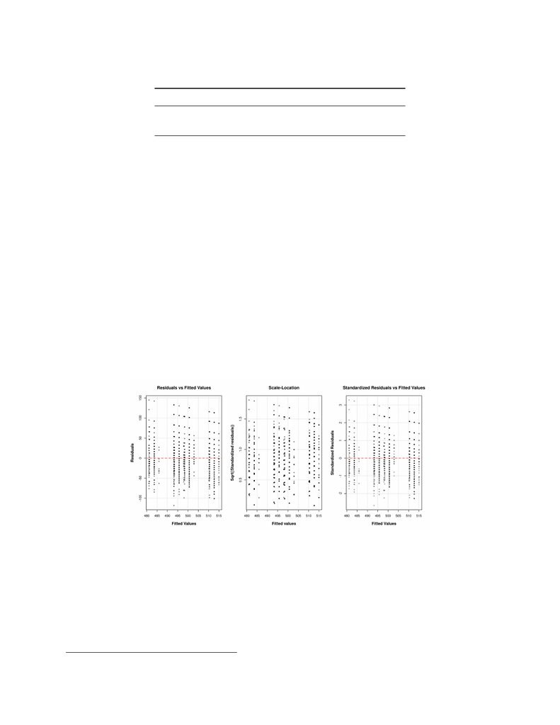

Table 5: Results of Mixed Eﬀects Additive Model (Random Variable)

Group Variance Standard Deviation

School (intercept) 192.2 13.85

Residual 1224.7 35.00

5 Sensitivity Analysis

5.1 Three Way ANOVA Model Diagnostics

The assumptions of any ANOVA model are summarized below

1

.

1. Variances of error terms are equal.

2. Error terms are independent.

3. Error terms are normally distributed.

4. No signiﬁcant outliers exist.

Note that since the experiment was randomized by design, the potential outcomes are independent

of the class type allocation, and therefore the error terms are known to be independent. In what

follows we aim to address each of these potential areas for concern.

Figure 6 shows the residual vs ﬁtted values plot, the scale-location plot, and the standardized

residual vs ﬁtted values plot for the model in Equation (1).

Figure 6: Diagnostic plots for Model 1

The residual vs ﬁtted value plot shows the residuals,

ˆ

Y

ijkl

−

¯

Y

ijk·

, for each (i, j, k). If the errors are

homoscedastic, we should expect to see equal variance across all factor levels and therefore a roughly

equal spread of data across all factor levels. In this case, for all but two factor levels, we observe the

expected result. Note, however, that there are two factor levels with a considerably smaller range

than the others. These smaller variance factor levels are associated with students in regular sized

classrooms in urban schools who are receiving free lunch (ﬁtted test scores of approximately 485.9)

1

See, e.g., Chapter 4 of [2].

11

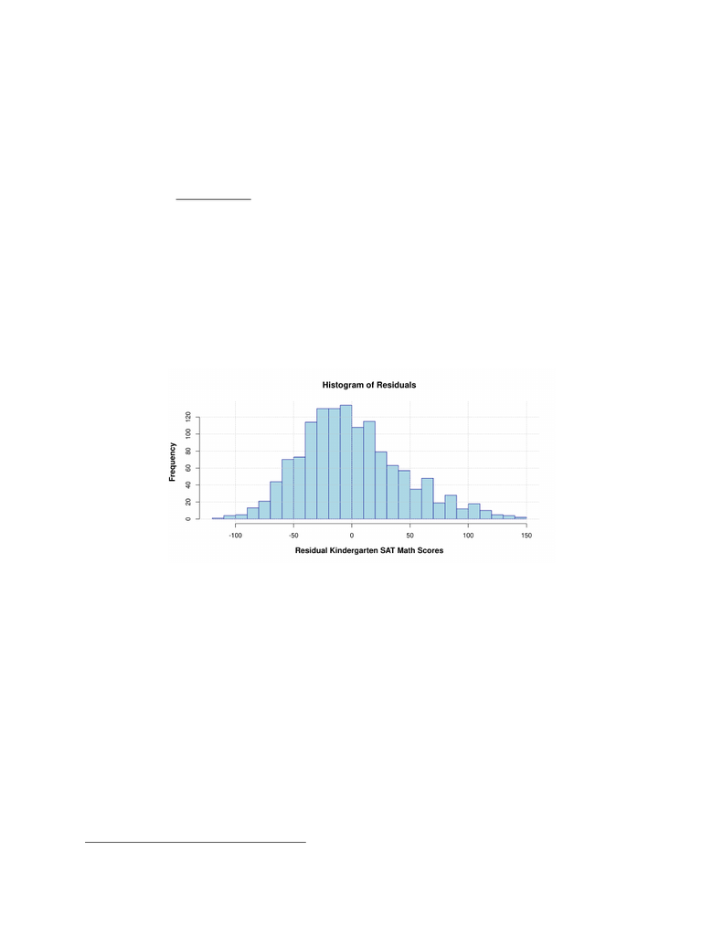

and students in regular sized classrooms in urban schools who are not receiving free lunch (ﬁtted

test scores of approximately 502.9). As seen in Section 3, the urban schools were by far the least

represented in the dataset, so the smaller perceived variance across these levels may be a bias due

to missing data and not a true feature of the population. More target research would be needed to

address this question.

The standardized residuals vs ﬁtted values plot on the right of Figure 6 shows the standardized

residuals

2

, e

i

/

p

MSE(1 − h

ii

), vs the ﬁtted values. This allows us to assess the existence of outliers

in the dataset; if signiﬁcant outliers are present, we would expect to see many standardized residuals

exceed, say, three standard deviations from the mean. In the present case, we see a few falling outside

of that region, but largely the data are as one would expect of a dataset without signiﬁcant outliers.

If the errors are truly N (0, σ

2

), then P(|X| > 3σ) ≈ 0.27% for any data point X. The number of

points exceeding three standard deviations from the mean is larger than 0.27% of the students in the

study, which is a sign of possible outliers. Nonetheless, the data shows that the number of outliers

is relatively small and with therefore be unlikely to have a signiﬁcant impact on the analysis.

Figure 7 shows a histogram of the residuals across all factor levels.

Figure 7: Residual histogram for Model 1

This histogram reinforces the comments made above: the residuals appear to be roughly normal

(and hence the errors may be normal as well), but the right tail is heavier than expected due to the

presence of large outliers. To further examine the impact of outliers on our residuals, we plot the

error distributions disaggregated by the relevant factor levels in our analysis in Figure 8.

2

Here, i indexes the data frame of values, not the factors

12

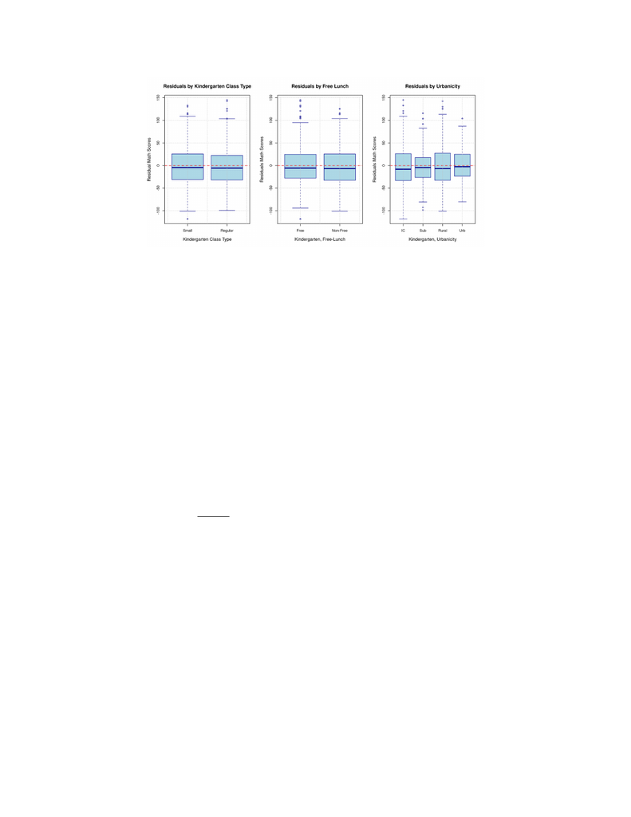

Figure 8: Residual boxplots by factor level for Model 1

Again, outliers are present throughout all factors and all factor levels. They appear to be the most

lunch than those that do not, and among inner city schools than those in other population densities.

In all, the assumptions of an ANOVA model are largely met, with the possible exception of outliers.

A future analysis could be done to remove these outliers from the dataset entirely before ﬁtting the

model.

5.2 Mixed Eﬀects Model Diagnostics

For our mixed eﬀects model which assesses if it is educationally advantageous to switch to smaller

classes after being assigned to regular sized classes, it is important to analyze the model diagnostics

to evaluate performance, detect potential confounding variables, and examine residual distributions.

Given our response variable math scores is continuous, it is appropriate to use the common Pearson

residual deﬁned as r

ij

=

Y

ij

−

ˆ

Y

ij

SD(Y

ij

)

, where Y

ij

is the observed value for row i and column j,

ˆ

Y

ij

is the

expected value, and SD(Y

ij

) is the standard deviation.

Ideally, our model will include all relevant covariates to explain as much information about the

response as possible, in which case the residuals would follow a normal distribution with constant

variance. This also follows from the assumptions of ANOVA stated in 5.1. First, we can examine

the residuals vs. ﬁtted plot, which shows the Pearson residuals against the predicted values

ˆ

Y

ij

.

13

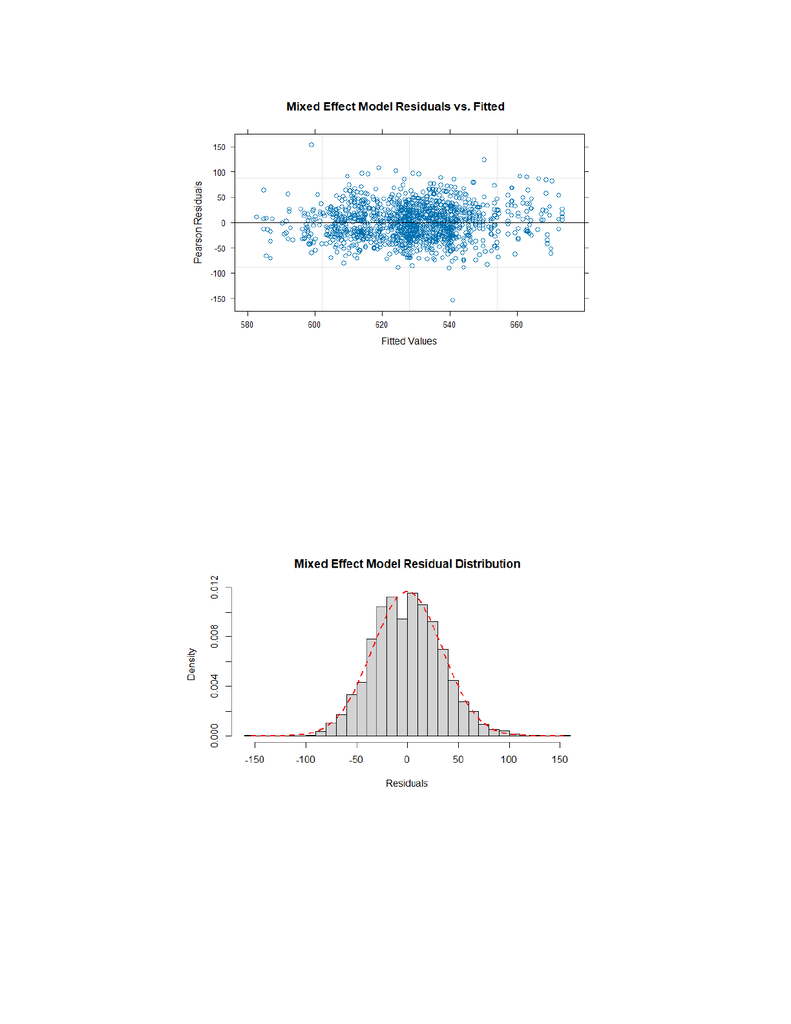

Figure 9: Mixed Eﬀect Model Residuals vs Fitted

The mixed eﬀects residuals vs. ﬁtted plot shows constant variance for all ﬁtted values, which is

reassuring that our model still predicts values well even at the high and low tails of the response

variable distribution. It is also good to see that our residuals are centered around the 0, which

validates the assumption 3 stated in section 5.1. Next, we can examine the distribution of the

residuals, to ensure that the model predicts values well and therefore the error terms are best

approximated by a normal distribution.

Figure 10: Mixed Eﬀect Model Residual Distribution

Our residual distribution displays a shape very closely related to the normal distribution. Another

takeaway from this plot is that the tail approximations seem to be very good, as there is no strong

skew on either side. This ensures that our model is accommodating for all possible sources of

variation in math scores, and our selected covariates have predictive capability. Finally, to ensure

14

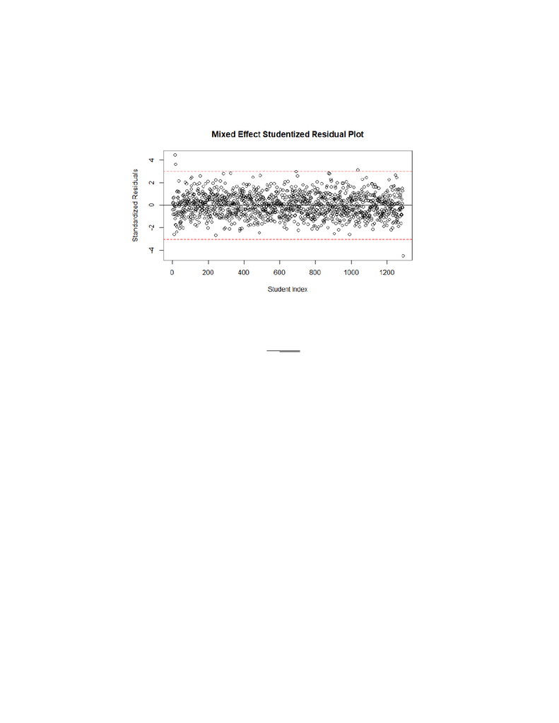

there are no signiﬁcant outliers in our dataset, we can observe the standardized Pearson residuals vs

the student index. This will help us gauge how the model behaves for large residuals, or equivalently

high observed values

ˆ

Y

ij

.

Figure 11: Mixed Eﬀect Model Studentized Residual Plot

The studentized residuals are deﬁned as r

ij

=

Y

ij

−

ˆ

Y

ij

ˆσ

√

1−h

ij

, where all other terms are deﬁned as before,

and ˆσ is the estimated error variance. The red dotted lines three standard deviations away from the

mean 0, to denote the bounds in which 99.7% of the data should fall under. This also follows from the

fact that the studentized Pearson residuals follow the standard normal distribution, mathematically

put: r

ij

∼ N(0, 1).

Our mixed eﬀect studentized residual plot shows only 3 or 4 values outside the 3 standard deviation

bounds, which denotes roughly 0.3% of the data. This is to be expected as per the 68-95-99.7 rule

of a normal distribution [5].

In all, our covariates in the mixed eﬀects model successfully captured all the necessary information in

the response variable math scores. This is demonstrated by the residuals having normal distribution

with mean 0 and variance σ

2

, r

ij

∼ N(0, σ

2

). The model does well at predicting values furthest

away from the expected value, as determined by the tails having no strong skew. The studentized

residual plot shows some values outside the three standard deviations away from the mean, however

this is to be expected.

6 Conclusion

In conclusion, we suﬃciently analyzed if smaller class sizes disproportionally beneﬁt lower income

students in early elementary school, and if it is educationally advantageous to switch to smaller class

sizes after being in regular sized classes. Our analysis and dataset were supported by the STAR

publication, Shizhe Chen’s lecture notes, and other related literature. We opted to use math scores

as the performance metric for students because we believe it captures all the meaningful insights

15

needed to evaluate their academic standing. Low income status was determined by a students’

participation in their schools’ free lunch program, which may not be the best representative measure,

however it is deemed appropriate for this analysis. We quantiﬁed switching to small classes as in

any of the 4 years of school from kindergarten through third grade, if the student was assigned

regular sized classes and at any point switched to small size classes. We chose to omit the students

in the regular sized classes with aide entirely because we did not want to group with with regular

sized classes because of confounding variable precaution, and sample size concerns.

To begin our analysis, we further investigated the dataset by examining the distribution of school

urbanicity (school location zone), the race proportions, and the number of schools by student income

status. This information aided us in understanding the distribution and initial behavior of the

covariates. It also helped us narrow down which predictors to include in which model. Next, we

visualized the diﬀerence by grade of the math and reading scores between genders. This gave us

appropriate understanding of the relationship between test scores by grade, along with how math

and reading scores relate. We also examined the non-compliance observations, or students who

opted out of the experiment to switch class sizes. We assumed this decision to be independent

for modeling purposes. The non-compliers are important to analyze to assess if it is educationally

advantageous to switch to smaller class sizes after being assigned to regular class sizes.

To assess if smaller class sizes disproportionally beneﬁt lower income students, we settled upon

the three way anova model with response variable math score, and covariates class type, free lunch

status, and school location (urbanicity). The F-test to detect if group means diﬀer for each covariate

group resulted in p-values much lower than our α = 0.05, signifying statistically diﬀerent means in

group class type and free lunch status. Contrary to our initial theory, urbanicity group means do

not have signiﬁcantly diﬀerent math scores.

To examine if it is educationally advantageous to switch to smaller class sizes after being assigned to

regular class sizes, we can implement the mixed eﬀects model with the random intercept term, trend

denoting class size for each year, gender, race, free lunch status, and teacher years of experience.

Table 4 outlines the results of our mixed eﬀects model, with race, and free lunch status being the

most signiﬁcant covariates. We also calculated the Intraclass Correlation Coeﬃcient, showing that

13.6% of the proportion of variance is explained by diﬀerence between schools.

We explored all statistical options needed to understand if smaller class sizes disproportionally eﬀect

lower income students, and if switching to smaller class sizes at any point in grades kindergarten

through third grade is academically advantageous, determined by math score increases. We used

appropriate models which explained variance well and resulted in signiﬁcant covariates. We deter-

mined the important predictors by the F-test for diﬀerence of group means. Our analysis consisted

of suﬃcient methods and we have reached a valid conclusion.

References

[1] C. M. Achilles, Helen Pate Bain, Fred Bellott, Jayne Boyd-Zaharias, Jeremy Finn, John Fol-

ger, John Johnston, and Elizabeth Word. Tennessee’s student teacher achievement ratio (star)

project. Dataset, 2008.

[2] Shizhe Chen. Statistical data science. Jupyter notebook, University of California, Davis, n.d.

Accessed: 2026-03-16.

16

[3] Jeremy D. Finn. Class size and students at risk: What is known? what is next? Teachers

College Record, 99(2):357–383, 1998.

[4] Jeremy D. Finn, Susan B. Gerber, and Jayne Boyd-Zaharias. Small classes in the early grades,

academic achievement, and graduating from high school. Journal of Educational Psychology,

97(2):214–223, 2005.

[5] Michael Galarnyk. Explaining the 68-95-99.7 rule for a normal distribution. Towards data

science, 2018.

[6] Gene V Glass. The eﬀectiveness of four educational interventions. Institute for Research on

Educational Finance and Governance, School of Education, Stanford University, Vol. 84, 1984.

[7] Diane Whitmore Schanzenbach. What have researchers learned from project star? In David W.

Grissmer and Kevin Ross, editors, Brookings Papers on Education Policy 2006/2007, pages

205–228. Brookings Institution Press, 2007.

[8] Benjamin Shear, Joseph A. Taylor, and Erin M. Fahle. Determinants of between-school variation

in student achievement: Results from us population data. Journal of Research on Educational

Eﬀectiveness, 2026.

17